# IBM HR Employee Attrition

### K-Nearest Neighbors (K-NN)

- [KNN Documentation](https://scikit-learn.org/stable/modules/generated/sklearn.neighbors.KNeighborsClassifier.html)

K-NN uses features from the training data to predict the values of new data points, which means the new data point will be assigned a value based on how similar it is to the data points in the training set.

Note: Scale will need to be changed with KNN because the magnitude at the end will affect the distance/output

The following steps are performed in K-NN:

- Select K
- Calculate distance (Euclidean, Manhattan, etc.)
- Find the K closest neighbors
- Take majority vote for labels

The “K” in the K-NN algorithm is the number of nearest neighbors we wish to take the vote from. Generally, K is taken to be an odd number when the number of classes is even, so as to get a majority vote. Let's say K=3. In that case, we will make a circle with the new data point as the center just as big as enclosing only the three nearest data points on the plane.

But before actually building the model, we need to identify the value of K to be used in K-NN. We will perform the following steps for the same.

- For every value of K (from 1 to 15), split the training set into a new train and validation sets (30 times)
- Scale the training data and the validation data
- Take the average of the error on these training and the validation sets for each value of K
- Plot the average train vs validation error for all Ks Choose the optimal K from the plot where the two errors are comparable

```python
%%time
knn = KNeighborsClassifier()

# We select the optimal value of K for which the error rate is the least in the validation data
# Let us loop over a few values of K to determine the optimal value of K

knn_many_split = {}

for k in range(1, 15):
  train_error = []
  test_error = []

  lista = []

  knn = KNeighborsClassifier(n_neighbors = k)

  for i in range(30): # why 30x, 30 iterations took x 1 min 9sec, try as many (more better but time is factor) we take a good average of the 30x
      # Split the training set into a new train and validation sets; size of datsset also important to decide
      # apply GridSearch to find the correct value
      x_train_new, x_val, y_train_new, y_val = train_test_split(x_train, y_train, test_size = 0.20)

      # Fitting K-NN on the training data
      knn.fit(x_train_new, y_train_new)

      # Calculating error on the training data and the validation data
      train_error.append(1 - knn.score(x_train_new, y_train_new))

      test_error.append(1 - knn.score(x_val, y_val))

  lista.append(sum(train_error)/len(train_error))

  lista.append(sum(test_error)/len(test_error))

  knn_many_split[k] = lista
```

```
CPU times: user 37.2 s, sys: 749 ms, total: 37.9 s
Wall time: 42.8 s
```

```python
knn_many_split
```

```
{1: [0.0, 0.22540453074433656],
 2: [0.11628189550425275, 0.16278317152103564],
 3: [0.10761441879303361, 0.17459546925566344],
 4: [0.13584447144592954, 0.1608414239482201],
 5: [0.12968813284730657, 0.16440129449838192],
 6: [0.14333738355609557, 0.16553398058252433],
 7: [0.14066423653300933, 0.16779935275080907],
 8: [0.14953422438234107, 0.1584142394822007],
 9: [0.1465370595382746, 0.15938511326860844],
 10: [0.15143782908059938, 0.1527508090614887],
 11: [0.14811664641555292, 0.1601941747572816],
 12: [0.15216686917780473, 0.16165048543689323],
 13: [0.15054678007290404, 0.15825242718446603],
 14: [0.15402997164844065, 0.1567961165048544]}
```

KNeighborsClassifier.score: Return the mean accuracy on the given test data and labels.

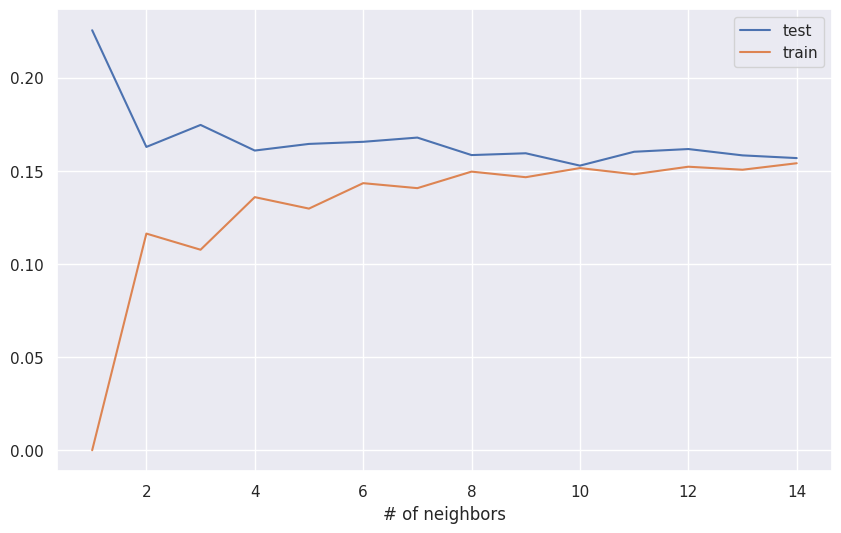

```python
kltrain = []
vltrain = []

for k, v in knn_many_split.items():
    kltrain.append(k)
    vltrain.append(knn_many_split[k][0])

kltest = []
vltest = []

for k, v in knn_many_split.items():
    kltest.append(k)
    vltest.append(knn_many_split[k][1])

# Plotting K vs Error
plt.figure(figsize = (10, 6))

plt.plot(kltest, vltest, label = 'test' )
plt.plot(kltrain, vltrain, label = 'train')

plt.legend()
plt.xlabel('# of neighbors')

plt.show()
```

KNN Classifier – Error vs Number of Neighbors (K)

- **Training error** increases with higher values of `k`, as the model becomes less flexible and less overfitted.
- **Validation (test) error** decreases sharply from k=1 to k=2, then stabilizes across k=3 to k=14.
- **Lowest validation error** is observed around **k=9 to k=14**, suggesting better generalization in this range.
- **Gap between train and test error** narrows as `k` increases — indicating reduced overfitting and better bias-variance tradeoff.

Choose `k` between **9–14** for stable performance with minimal test error.

```python
# Define K-NN model
knn = KNeighborsClassifier(n_neighbors = 13)
```

```python
# Fitting data to the K-NN model

knn.fit(x_train,y_train)
```

```
KNeighborsClassifier(n_neighbors=13)
```

```
              precision    recall  f1-score   support

           0       0.85      1.00      0.92       863
           1       1.00      0.08      0.16       166

    accuracy                           0.85      1029
   macro avg       0.93      0.54      0.54      1029
weighted avg       0.87      0.85      0.80      1029
```

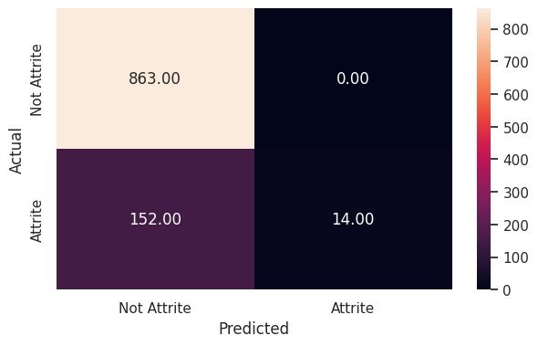

```python
# Checking the performance of K-NN model on the training data
y_pred_train_knn = knn.predict(x_train)

metrics_score(y_train, y_pred_train_knn)
```

```
              precision    recall  f1-score   support

           0       0.86      0.99      0.92       370
           1       0.75      0.13      0.22        71

    accuracy                           0.85       441
   macro avg       0.80      0.56      0.57       441
weighted avg       0.84      0.85      0.81       441
```

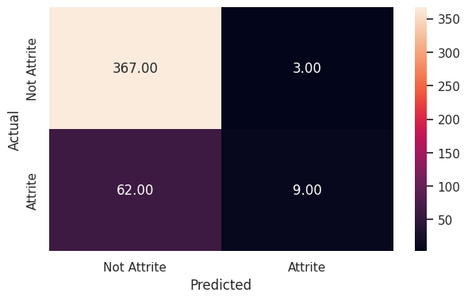

```python
# Checking the performance of K-NN model on the testing data
y_pred_test_knn = knn.predict(x_test)

metrics_score(y_test, y_pred_test_knn)
```

Recall Method:

Before (Logistic Regression, Default Threshold 0.5)

- Train 0: 0.98, Test 0: 0.95
- Train 1: **0.52**, Test 1: **0.56**

Logistic Regression Post Threshold Change (Threshold = 0.35)

- Train 0: 0.94, Test 0: 0.90
- Train 1: **0.63**, Test 1: **0.65**

K-NN Model (Current Run)

- Train 0: 1.00, Test 0: 0.99
- Train 1: **0.08**, Test 1: **0.13**

Observations:

- **K-NN performs poorly on minority class (Attrition = 1)**, with extremely low recall: **only 13% on test set**.
- The model is **highly biased toward the majority class** (Not Attrite), achieving perfect or near-perfect recall on class 0.
- **High overall accuracy** (~85%) is misleading due to class imbalance.
- Indicates strong **underfitting for minority class** and poor generalization.

Let's try to fine tune this model and check if we could increase the Recall.

### Using GridSearchCV for Hyperparameter tuning of the model

- Hyperparameter tuning is tricky in the sense that there is no direct way to calculate how a change in the hyperparameter value will reduce the loss of your model, so we usually resort to experimentation.
- Grid search is a model tuning technique that attempts to compute the optimum values of hyperparameters.
- It is an exhaustive search that is performed on specific parameter values of a model.
- The parameters of the estimator/model used to apply these methods are optimized by cross-validated grid-search over a parameter grid.
- n_neighbors
  - Number of neighbors to use.
- weights={'uniform', 'distance'}
  - uniform : uniform weights. All points in each neighborhood are weighted equally.
  - distance : weight points by the inverse of their distance. In this case, the closest neighbors of a query point will have a greater influence than neighbors that are further away.

[KNeighborsClassifier Documentation](https://scikit-learn.org/stable/modules/generated/sklearn.neighbors.KNeighborsClassifier.html)

```python
%%time
# Parameters to GridSearchCV
params_knn = {'n_neighbors': np.arange(3, 15), 'weights': ['uniform', 'distance'], 'p': [1, 2]}

grid_knn = GridSearchCV(estimator = knn, param_grid = params_knn, scoring = 'recall', cv = 10)

model_knn = grid_knn.fit(x_train,y_train)

knn_estimator = model_knn.best_estimator_
```

```
CPU times: user 8.85 s, sys: 36.8 ms, total: 8.88 s
Wall time: 9.06 s
```

```python
knn_estimator
```

```
KNeighborsClassifier(n_neighbors=np.int64(4), p=1, weights='distance')
```

- We have found the best hyperparameters for the K-NN classifier. Let's use these parameters to build the new K-NN model and find the recall of that model.
- p = 1 : manhattan distance
- n_neighbors = 4
- weights = distance

```python
# Fit the best estimator on the training data
knn_estimator.fit(x_train, y_train)
```

```
KNeighborsClassifier(n_neighbors=np.int64(4), p=1, weights='distance')
```

```
              precision    recall  f1-score   support

           0       1.00      1.00      1.00       863
           1       1.00      1.00      1.00       166

    accuracy                           1.00      1029
   macro avg       1.00      1.00      1.00      1029
weighted avg       1.00      1.00      1.00      1029
```

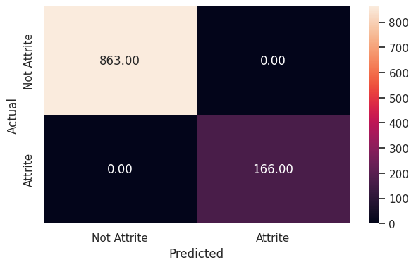

```python
y_pred_train_knn_estimator = knn_estimator.predict(x_train)

metrics_score(y_train, y_pred_train_knn_estimator)
```

```
              precision    recall  f1-score   support

           0       0.87      0.95      0.91       370
           1       0.50      0.25      0.34        71

    accuracy                           0.84       441
   macro avg       0.68      0.60      0.62       441
weighted avg       0.81      0.84      0.82       441
```

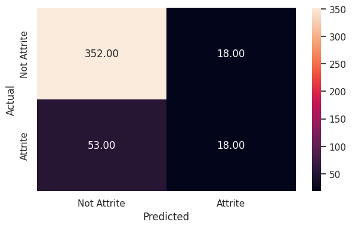

```python
y_pred_test_knn_estimator = knn_estimator.predict(x_test)

metrics_score(y_test, y_pred_test_knn_estimator)
```

Recall Method:

Before (Logistic Regression, Threshold 0.5)

- Train 0: 0.98, Test 0: 0.95
- Train 1: **0.52**, Test 1: **0.56**

Logistic Regression Post Threshold Adjustment (Threshold = 0.35)

- Train 0: 0.94, Test 0: 0.90
- Train 1: **0.63**, Test 1: **0.65**

K-NN (Before GridSearch)

- Train 0: 1.00, Test 0: 0.99
- Train 1: **0.08**, Test 1: **0.13**

K-NN (After GridSearchCV Optimization)

- Train 0: 1.00, Test 0: 0.95
- Train 1: **1.00**, Test 1: **0.25**

Observations:

- **GridSearchCV improved recall on the test set** from 13% to **25%**, and fully overfitted on the train set (100% recall).
- The model is now **perfectly fit to training data**, showing signs of overfitting.
- Despite optimization, **test set recall is still low (25%)**, indicating that KNN struggles with generalizing attrition cases.
- **Test accuracy is high (84%)**, but misleading due to class imbalance.
- The best KNN found: `n_neighbors = 4`, `p = 1` (Manhattan), `weights = 'distance'`.
- Suggestion: Consider **SMOTE**, **ensemble methods**, or **logistic regression with threshold tuning** for better recall and generalization.

## Feature Importance using SHAP Library

With the aid of a visualization tool called SHAP, or SHapley Additive exPlanations, a machine learning model's output can be made more understandable. By calculating the contribution of each feature to the prediction, it can be used to explain the prediction by any model. The direction of the relationship (positive or negative) between the predictive variable and the target variable is also indicated by the SHAP values. A technique called SHAP values (SHapley Additive exPlanations), which is based on cooperative game theory, is used to make machine learning models more transparent and understandable.

In a machine learning setting, a Shapley value is the contribution of a feature value to the difference between the actual prediction and the mean prediction.

### SHAP Barplot

```python
# !pip install shap
```

We plot the mean absolute value for each feature column as a bar chart if an Explainer with many samples is passed.

We determine the mean absolute SHAP values across all observations for each feature. Since we do not want positive and negative numbers to cancel one another out, we take the absolute values. A mean SHAP plot will allow us to visualize the aggregated SHAP values.

SHAP value helps us quantify feature's contribution towards a prediction. SHAP value closer to zero means the feature contributes little to the prediction whereas SHAP value away from zero indicates the feature contributes more. So, large positive/negative SHAP values are found in features that significantly affect the model's predictions.

In the bar plot below, each feature is represented by a separate bar.

```python
# Importing the SHAP library
import shap as sh
```

```python
%%time
# Fitting the Explainer
explainer = sh.Explainer(knn_estimator.predict, x_test)

# Calculating the SHAP values. The below code might take some time to run.
shap_values = explainer(x_test)
```

```
PermutationExplainer explainer: 442it [13:58,  1.90s/it]
```

```
CPU times: user 13min 46s, sys: 1.12 s, total: 13min 47s
Wall time: 13min 58s
```

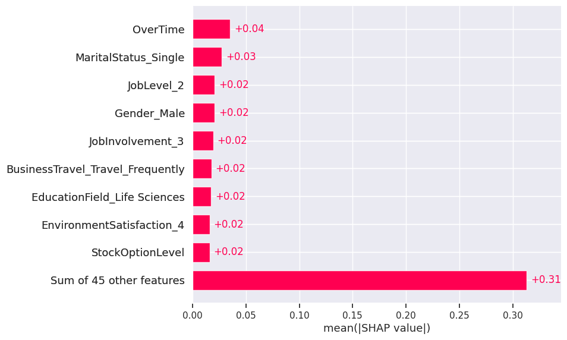

```python
sh.plots.bar(shap_values)
```

Note: By default the bar plot only shows a maximum of ten bars, but this can be controlled with the max_display parameter.

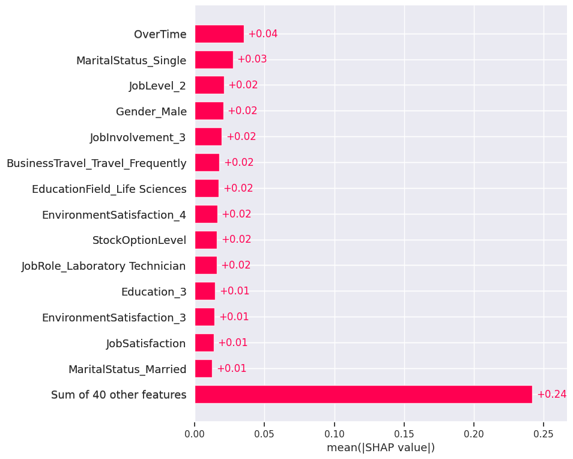

```python
sh.plots.bar(shap_values, max_display=15)
```

### Summary Plot

The SHAP summary plot displays how each instance's (row of data) features contribute to the final prediction.

- Here, the Y-axis indicates the variable name, in order of importance from top to bottom and the X-axis is the SHAP value, which indicates the impact on the model output.
- Each dot represents a row from the original dataset.
- The color of the data shows the features values. This allows us to see the how the SHAP values changes as the feature value changes. The color map on the right helps to understand which value is low and which value is high. If a feature has boolean values, it will take two colors, and for continuous features, it can contain the whole spectrum.

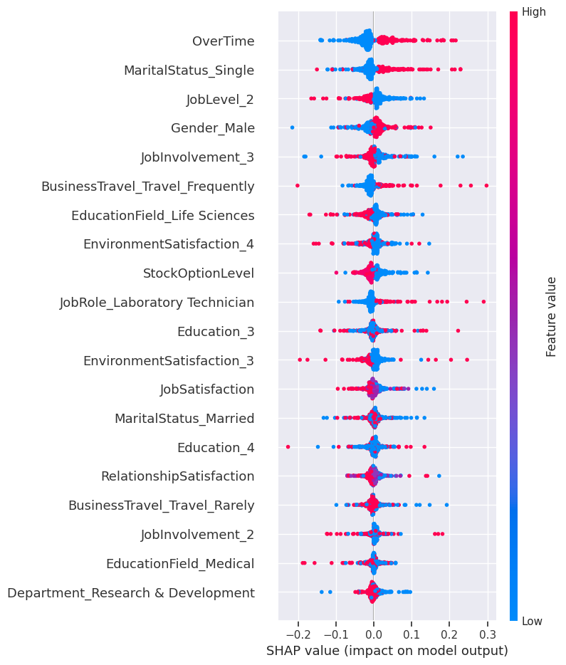

```python
sh.summary_plot(shap_values)
```

### Force Plot

The SHAP force plot shows you exactly which feature had the most influence on the model's prediction for a single observation.

- issue of using this is feature for only one e.g., x_test
  - this does it one one

The below graph explains a single prediction from the test set.

```
WARNING:shap:Using 1029 background data samples could cause slower run times. Consider using shap.sample(data, K) or shap.kmeans(data, K) to summarize the background as K samples.
```

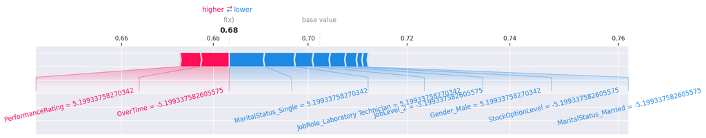

```python
explainer = sh.KernelExplainer(knn.predict_proba, x_train)

shap_values1 = explainer.shap_values(x_test.iloc[0,:])

sh.force_plot(explainer.expected_value[0], shap_values1[:, 0], x_test.iloc[0,:], matplotlib = True, text_rotation=13, link='logit')
```

## Other Models

We will be building 2 additional models:

- Linear Discriminant Analysis (LDA)
- Quadratic Discriminant Analysis (QDA)

### Linear Discriminant Analysis

Linear discriminant analysis (LDA) is generally used to classify patterns between two classes; however, it can be extended to classify multiple patterns. LDA assumes that all classes are linearly separable and according to this, multiple linear discrimination functions representing several hyperplanes in the feature space are created to distinguish between the classes. If there are two classes, then the LDA draws one hyperplane and projects the data onto this hyperplane in such a way as to maximize the separation of the two categories. This hyperplane is created according to two criteria considered simultaneously:

- Maximizing the distance between the means of two classes.
- Minimizing the variation between each category.

```python
# Fitting the LDA model
lda = LinearDiscriminantAnalysis()

lda.fit(x_train, y_train)
```

```
LinearDiscriminantAnalysis()
```

Checking Model Performance

```
              precision    recall  f1-score   support

           0       0.91      0.97      0.94       863
           1       0.78      0.50      0.61       166

    accuracy                           0.90      1029
   macro avg       0.84      0.74      0.77      1029
weighted avg       0.89      0.90      0.89      1029
```

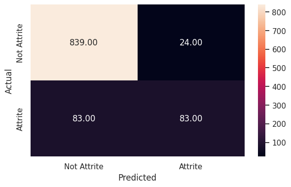

```python
# Checking model performance of LDA
y_pred_train_lda = lda.predict(x_train)

metrics_score(y_train, y_pred_train_lda)
```

- The reported average includes the macro average which averages the unweighted mean per label, and the weighted average which averages the support-weighted mean per label.
- In classification, the class of interest is considered the positive class. Here, the class of interest is 1, i.e., identifying the employees at risk of attrition.

Reading the confusion matrix (clockwise from top left):

- True Negative (Actual = 0, Predicted = 0): Model predicts that an employee would not attrite and the employee does not attrite
- False Positive (Actual = 0, Predicted = 1): Model predicts that an employee would attrite but the employee does not attrite
- True Positive (Actual = 1, Predicted = 1): Model predicts that an employee would attrite and the employee actually attrites
- False Negative (Actual = 1, Predicted = 0): Model predicts that an employee would not attrite but the employee attrites

LDA Model – Training Performance Summary

- **Overall Accuracy** is **90%**, reflecting strong model performance on the training data.
- **Recall (Attrite = 1)** is **0.50**, meaning the model correctly identifies only half of the actual attrition cases.
- **Precision (Attrite = 1)** is **0.78**, suggesting the model makes relatively few false positive attrition predictions.
- **F1-Score for Attrition** is **0.61**, indicating moderate balance between precision and recall.
- **Confusion Matrix Insight**: 83 attrition cases were correctly identified, but 83 were missed—highlighting room for improvement in recall.
- LDA handles the class imbalance fairly but still needs tuning to boost attrition (class 1) detection sensitivity.

We have built the LDA model. Now, let's check the coefficients and find which variables are leading to attrition and which can help to reduce the attrition.

```python
# Creating the list of column names
cols = X.columns

# Saving coefficients of LDA model
coef_lda = lda.coef_

# Printing the cofficients of LDA
pd.DataFrame(coef_lda, columns = cols).T.sort_values(by = 0, ascending = False)
```

|  | 0 |
| --- | --- |
| OverTime | 0.187099 |
| JobRole_Human Resources | 0.167567 |
| NumCompaniesWorked | 0.163415 |
| BusinessTravel_Travel_Frequently | 0.157675 |
| MonthlyRate | 0.135090 |
| Department_Research & Development | 0.130448 |
| YearsAtCompany | 0.125518 |
| TotalWorkingYears | 0.117596 |
| MaritalStatus_Single | 0.115994 |
| DistanceFromHome | 0.111454 |
| Department_Sales | 0.104647 |
| JobRole_Sales Representative | 0.099742 |
| YearsSinceLastPromotion | 0.095170 |
| JobRole_Sales Executive | 0.082993 |
| HourlyRate | 0.061785 |
| BusinessTravel_Travel_Rarely | 0.059359 |
| Gender_Male | 0.051583 |
| Education_4 | 0.051198 |
| Education_5 | 0.049931 |
| Education_2 | 0.041181 |
| MaritalStatus_Married | 0.034129 |
| Education_3 | 0.032357 |
| JobLevel_5 | 0.014840 |
| JobRole_Laboratory Technician | 0.008475 |
| JobRole_Manufacturing Director | 0.007485 |
| JobLevel_3 | -0.012726 |
| PerformanceRating | -0.016734 |
| JobRole_Manager | -0.020734 |
| PercentSalaryHike | -0.026645 |
| EducationField_Technical Degree | -0.028423 |
| JobLevel_4 | -0.032286 |
| StockOptionLevel | -0.063195 |
| EducationField_Marketing | -0.072740 |
| JobRole_Research Scientist | -0.075508 |
| DailyRate | -0.079371 |
| JobRole_Research Director | -0.079517 |
| RelationshipSatisfaction | -0.085418 |
| WorkLifeBalance | -0.093635 |
| JobLevel_2 | -0.106205 |
| EducationField_Medical | -0.116581 |
| YearsInCurrentRole | -0.131198 |
| EnvironmentSatisfaction_3 | -0.131891 |
| EnvironmentSatisfaction_2 | -0.134722 |
| EducationField_Other | -0.138363 |
| EnvironmentSatisfaction_4 | -0.138895 |
| JobSatisfaction | -0.143173 |
| EducationField_Life Sciences | -0.144498 |
| TrainingTimesLastYear | -0.177034 |
| YearsWithCurrManager | -0.186281 |
| JobInvolvement_2 | -0.193506 |
| JobInvolvement_3 | -0.219564 |
| JobInvolvement_4 | -0.255514 |
| Age | -0.406632 |
| MonthlyIncome | -0.498881 |

Precision-Recall Curve for LDA

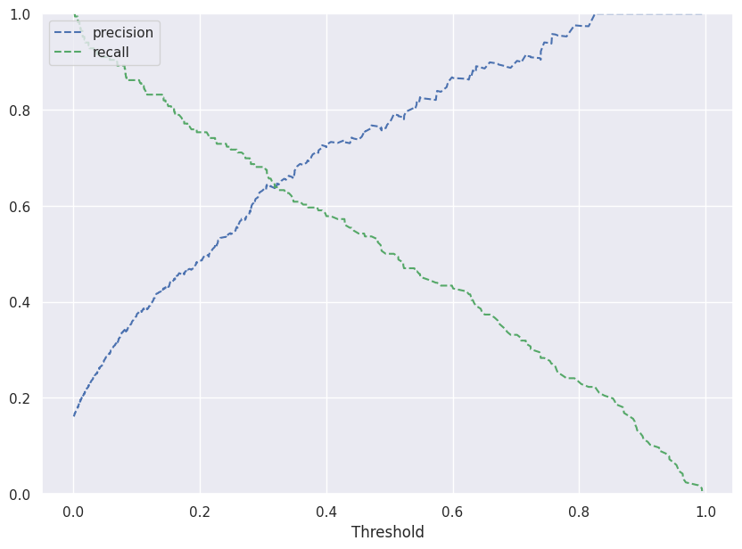

```python
y_scores_lda = lda.predict_proba(x_train) # predict_proba gives the probability of each observation belonging to each class

precisions_lda, recalls_lda, thresholds_lda = precision_recall_curve(y_train, y_scores_lda[:, 1])

# Plot values of precisions, recalls, and thresholds
plt.figure(figsize = (10, 7))

plt.plot(thresholds_lda, precisions_lda[:-1], 'b--', label = 'precision')

plt.plot(thresholds_lda, recalls_lda[:-1], 'g--', label = 'recall')

plt.xlabel('Threshold')

plt.legend(loc = 'upper left')

plt.ylim([0, 1])

plt.show()
```

Precision-Recall Curve for LDA – Observations

- The graph shows the typical trade-off between **precision** and **recall** across different classification thresholds.
- As the threshold increases:
  - **Precision** rises (fewer false positives).
  - **Recall** drops (more false negatives).
- The **intersection point** of precision and recall occurs around **threshold ≈ 0.35**, where both are approximately balanced.
- This threshold could be a candidate for optimizing the F1-score or choosing a suitable balance between false positives and false negatives, depending on business goals.

Threshold Insight

- **Threshold ≈ 0.35** is a good starting point for tuning, as it balances precision and recall fairly well.
- Lower thresholds prioritize recall (catching more attrition cases), while higher thresholds improve precision (fewer false attrition predictions).

Let's check the model performance at this threshold

```
              precision    recall  f1-score   support

           0       0.93      0.94      0.94       863
           1       0.68      0.61      0.64       166

    accuracy                           0.89      1029
   macro avg       0.80      0.78      0.79      1029
weighted avg       0.89      0.89      0.89      1029
```

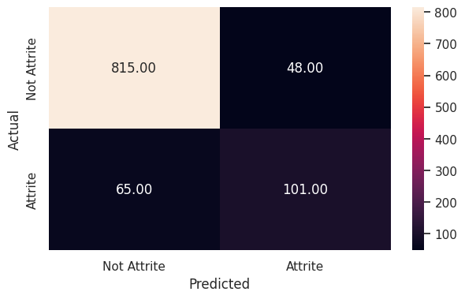

```python
optimal_threshold1 = .35

y_pred_train_lda = lda.predict_proba(x_train)

metrics_score(y_train, y_pred_train_lda[:,1] > optimal_threshold1)
```

LDA with Threshold = 0.35 – Observations

- **Improved Recall (Class 1)**: Recall increased to 0.61 from 0.50, meaning more attrition cases are now correctly identified.
- **Trade-off in Precision**: Precision for attrition slightly dropped to 0.68, indicating more false positives.
- **Balanced F1-Score**: F1-score for class 1 improved to 0.64, reflecting better balance between precision and recall.
- **Accuracy Stable**: Overall accuracy remains high at 89%, suggesting good overall model fit after threshold tuning.
- **Confusion Matrix Insight**: 101 attrite cases correctly predicted vs. 65 missed (false negatives).

Let's check the model performance on the test data

```
              precision    recall  f1-score   support

           0       0.93      0.89      0.91       370
           1       0.54      0.66      0.59        71

    accuracy                           0.85       441
   macro avg       0.74      0.78      0.75       441
weighted avg       0.87      0.85      0.86       441
```

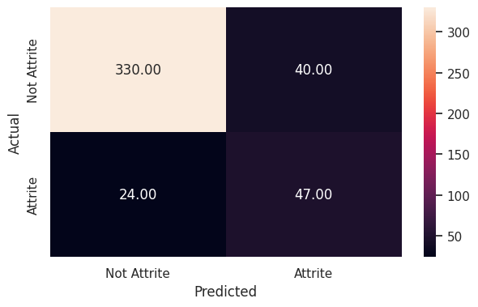

```python
# Checking performance on the test data
optimal_threshold1 = .35

y_pred_test_lda = lda.predict_proba(x_test)

metrics_score(y_test, y_pred_test_lda[:,1] > optimal_threshold1)
```

LDA (Test Set) with Threshold = 0.35 – Observations

- **Recall (Attrition) Improved**: Recall for class 1 increased to 0.66, capturing more actual attrition cases compared to default threshold.
- **Precision Trade-Off**: Precision dropped slightly to 0.54, indicating more false positives for attrition prediction.
- **F1-Score Balanced**: F1-score for attrition reached 0.60, reflecting a balanced performance after threshold tuning.
- **Strong Accuracy**: Overall accuracy remains high at 85%, showing reliable generalization to unseen data.
- **Confusion Matrix Insight**: 47 true positives vs. 24 false negatives — better than default threshold.

### Quadratic Discriminant Analysis

Quadratic discriminant analysis (QDA) is a probabilistic parametric classification technique that represents an evolution of LDA for nonlinear class separations. QDA, like LDA, is based on the hypothesis that the probability density distributions are multivariate normal but, in this case, the dispersion is not the same for all of the categories.

```python
# Fitting QDA model
qda = QuadraticDiscriminantAnalysis()

qda.fit(x_train, y_train)
```

```
QuadraticDiscriminantAnalysis()
```

```
              precision    recall  f1-score   support

           0       1.00      0.14      0.25       863
           1       0.18      1.00      0.31       166

    accuracy                           0.28      1029
   macro avg       0.59      0.57      0.28      1029
weighted avg       0.87      0.28      0.26      1029
```

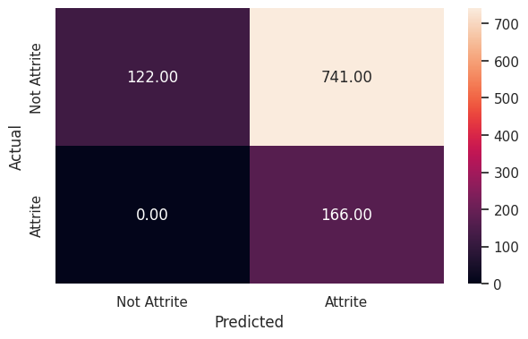

```python
# Checking model performance on the training data
y_pred_train_qda = qda.predict(x_train)

metrics_score(y_train, y_pred_train_qda)
```

```
              precision    recall  f1-score   support

           0       0.93      0.15      0.26       370
           1       0.18      0.94      0.30        71

    accuracy                           0.28       441
   macro avg       0.55      0.55      0.28       441
weighted avg       0.81      0.28      0.26       441
```

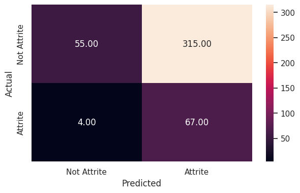

```python
# Checking performance of the model on the test data
y_pred_test_qda = qda.predict(x_test)

metrics_score(y_test, y_pred_test_qda)
```

## Conclusion and Recommendations

Final Recommendations

- **Use Logistic Regression with threshold = 0.35** in production for its balanced performance and interpretability.
- **Apply feature engineering**:
  - Bin skewed variables like `MonthlyIncome`, `DistanceFromHome`
  - Group low-frequency job roles or departments
- **Use SMOTE or class weighting** to address class imbalance in future models (especially for KNN/QDA).
- **Incorporate SHAP or feature importance** visuals in HR dashboards to build trust and explainability.
- **Monitor and retrain**:
  - Track actual attrition post-deployment
  - Periodically evaluate for model drift
- **Leverage model predictions** to guide employee retention actions and preempt voluntary attrition.

```python
notebook_path = '/content/drive/MyDrive/My DS DA/Employee Attrition/IBM HR Employee Attrition.ipynb'

!jupyter nbconvert --to html "{notebook_path}"

from google.colab import files
files.download('/content/drive/MyDrive/My DS DA/Employee Attrition/IBM HR Employee Attrition.html')
```

```
[NbConvertApp] Converting notebook /content/drive/MyDrive/My DS DA/Employee Attrition/IBM HR Employee Attrition.ipynb to html
[NbConvertApp] WARNING | Alternative text is missing on 24 image(s).
[NbConvertApp] Writing 2533091 bytes to /content/drive/MyDrive/My DS DA/Employee Attrition/IBM HR Employee Attrition.html
```